# Data Analysis - EAMT Statistical Consulting

### Improved Plots

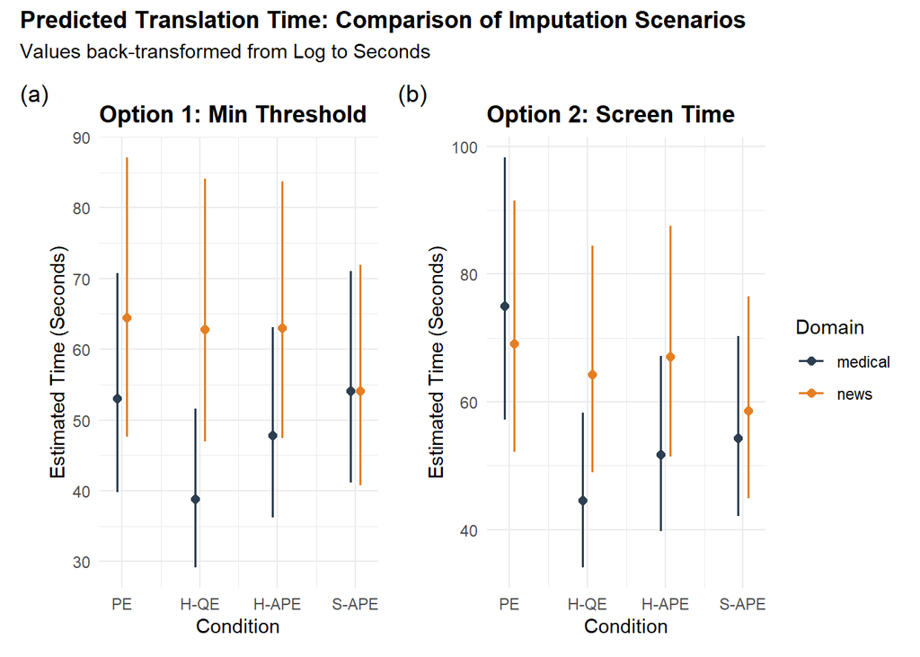

```r
my_colors <- c("medical" = "#2c3e50", "news" = "#e67e22") # Blu notte e Arancione
my_labels <- c("PE", "H-QE", "H-APE", "S-APE")

p11 <- plot(eff_int) +
  scale_x_continuous(breaks = 1:4, labels = my_labels) +
  scale_color_manual(values = my_colors) +
  labs(
    title = "Option 1: Min Threshold",
    x = "Condition",
    y = "Estimated Time (Seconds)",
    colour = "Domain"
  ) +
  theme_minimal()
p22 <- plot(eff_int_hyb) +
  scale_x_continuous(breaks = 1:4, labels = my_labels) +
  scale_color_manual(values = my_colors) +
  labs(
    title = "Option 2: Screen Time",
    x = "Condition",
    y = "Estimated Time (Seconds)",
    colour = "Domain"
  ) +
  theme_minimal()
combined_plot <- p11 + p22 +
  plot_layout(guides = "collect") +
  plot_annotation(
    title = "Predicted Translation Time: Comparison of Imputation Scenarios",
    subtitle = "Values back-transformed from Log to Seconds",
    tag_levels = 'a',
    tag_prefix = '(',
    tag_suffix = ')'
  ) &
  theme(
    legend.position = "right",
    plot.title = element_text(face = "bold")
  )

combined_plot
```

# Model Building - Keystrokes

### Analysis of outcome variable distribution

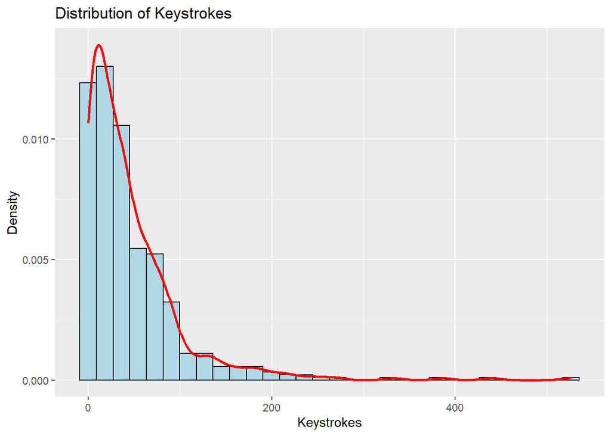

```r
ggplot(data, aes(x = keystrokes)) +
  geom_histogram(aes(y = ..density..),
                 bins = 30,
                 fill = "lightblue",
                 color = "black") +
  geom_density(color = "red", size = 1) +
  labs(title = "Distribution of Keystrokes",
       x = "Keystrokes",
       y = "Density")
```

## Tweedie GLMM

The Tweedie distribution is a member of the Exponential Dispersion Family. Here, it is specifically a Compound Poisson-Gamma distribution.

It acts as a single mathematical framework that handles two processes at once: 1) The Discrete Part (Poisson) models the probability of an event occurring (e.g., whether the translator chooses to edit the sentence or leave it at 0 keystrokes); The Continuous Part (Gamma) models the magnitude of the event (e.g., if they do edit, how many keystrokes are required)

```r
full_model <- glmmTMB(keystrokes ~ condition * domain + num_characters + num_minor + num_major + MT_Quality + Difficulty +
                   (1 | PET) + (1 | text_name) + (1 | Sent_id),
                 family = tweedie(), data = data, REML = FALSE)
summary(full_model)
```

```
##  Family: tweedie  ( log )
## Formula:
## keystrokes ~ condition * domain + num_characters + num_minor +
##     num_major + MT_Quality + Difficulty + (1 | PET) + (1 | text_name) +
##     (1 | Sent_id)
## Data: data
##
##       AIC       BIC    logLik -2*log(L)  df.resid
##    4540.6    4616.3   -2252.3    4504.6       478
##
## Random effects:
##
## Conditional model:
##  Groups    Name        Variance Std.Dev.
##  PET       (Intercept) 0.22448  0.4738
##  text_name (Intercept) 0.07371  0.2715
##  Sent_id   (Intercept) 0.01331  0.1154
## Number of obs: 496, groups:  PET, 8; text_name, 8; Sent_id, 10
##
## Dispersion parameter for tweedie family (): 5.07
##
## Conditional model:
##                         Estimate Std. Error z value Pr(>|z|)
## (Intercept)            3.1923025  0.3131078  10.196  < 2e-16 ***
## condition2            -0.2059139  0.1724809  -1.194 0.232542
## condition3            -0.0322123  0.1629450  -0.198 0.843289
## condition4            -0.1364385  0.1593411  -0.856 0.391850
## domainnews            -0.0585156  0.2463233  -0.238 0.812226
## num_characters         0.0035341  0.0004367   8.092 5.85e-16 ***
## num_minor              0.0615679  0.0238404   2.583 0.009809 **
## num_major              0.0762211  0.0462809   1.647 0.099574 .
## MT_Quality            -0.2096219  0.0622165  -3.369 0.000754 ***
## Difficulty             0.0871202  0.0546948   1.593 0.111196
## condition2:domainnews  0.2543400  0.2077050   1.225 0.220754
## condition3:domainnews  0.1797527  0.2036987   0.882 0.377537
## condition4:domainnews  0.0474774  0.2064133   0.230 0.818083
## ---
## Signif. codes:  0 '***' 0.001 '**' 0.01 '*' 0.05 '.' 0.1 ' ' 1
```

```r
full_model$sdr$pdHess
```

```
## [1] TRUE
```

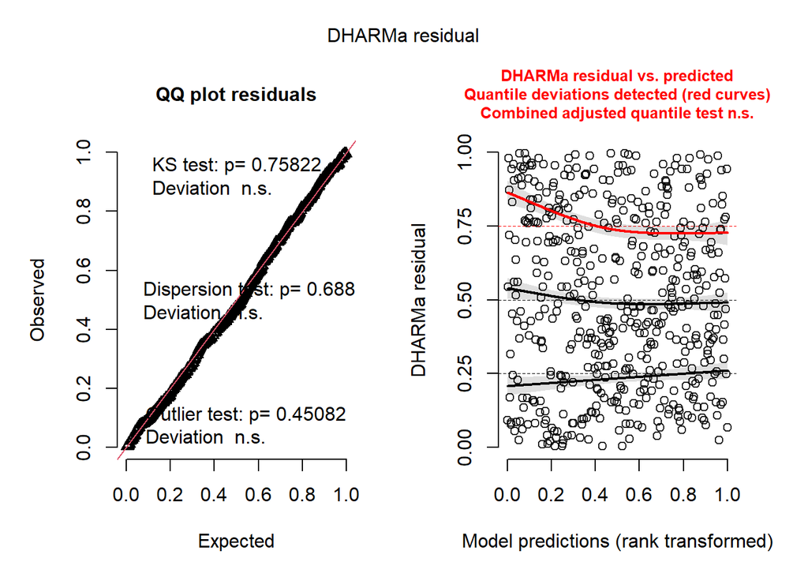

```r
res <- simulateResiduals(full_model)
plot(res)
```

```r
# A more simplified model
refined_model <- glmmTMB(keystrokes ~ condition * domain +
                             num_characters + num_minor + num_major +
                             MT_Quality + Difficulty +
                             (1 | PET) + (1 | text_name),
                           family = tweedie(),
                           data = data)
summary(refined_model)
```

```
##  Family: tweedie  ( log )
## Formula:
## keystrokes ~ condition * domain + num_characters + num_minor +
##     num_major + MT_Quality + Difficulty + (1 | PET) + (1 | text_name)
## Data: data
##
##       AIC       BIC    logLik -2*log(L)  df.resid
##    4541.8    4613.3   -2253.9    4507.8       479
##
## Random effects:
##
## Conditional model:
##  Groups    Name        Variance Std.Dev.
##  PET       (Intercept) 0.2224   0.4716
##  text_name (Intercept) 0.0716   0.2676
## Number of obs: 496, groups:  PET, 8; text_name, 8
##
## Dispersion parameter for tweedie family (): 5.08
##
## Conditional model:
##                         Estimate Std. Error z value Pr(>|z|)
## (Intercept)            3.2173385  0.3079667  10.447  < 2e-16 ***
## condition2            -0.2090329  0.1728145  -1.210 0.226440
## condition3            -0.0284707  0.1636996  -0.174 0.861928
## condition4            -0.1322924  0.1602395  -0.826 0.409036
## domainnews            -0.0433218  0.2445704  -0.177 0.859403
## num_characters         0.0033949  0.0003983   8.525  < 2e-16 ***
## num_minor              0.0587039  0.0233259   2.517 0.011847 *
## num_major              0.0970654  0.0447759   2.168 0.030174 *
## MT_Quality            -0.2068991  0.0626836  -3.301 0.000964 ***
## Difficulty             0.0846716  0.0550203   1.539 0.123825
## condition2:domainnews  0.2405202  0.2089792   1.151 0.249762
## condition3:domainnews  0.1911759  0.2051732   0.932 0.351451
## condition4:domainnews  0.0493353  0.2081055   0.237 0.812604
## ---
## Signif. codes:  0 '***' 0.001 '**' 0.01 '*' 0.05 '.' 0.1 ' ' 1
```

### 1. Scale variables to get numerical stability and Check stability

```r
final_recovery_model <- glmmTMB(
  keystrokes ~ condition * domain +
    scale(num_characters) +
    scale(num_minor) +
    scale(num_major) +
    scale(MT_Quality) +
    scale(Difficulty) +
    (1 | PET) +
    (1 | text_name / Sent_id),
  family = tweedie(),
  data = data
)

final_recovery_model$sdr$pdHess
```

```
## [1] TRUE
```

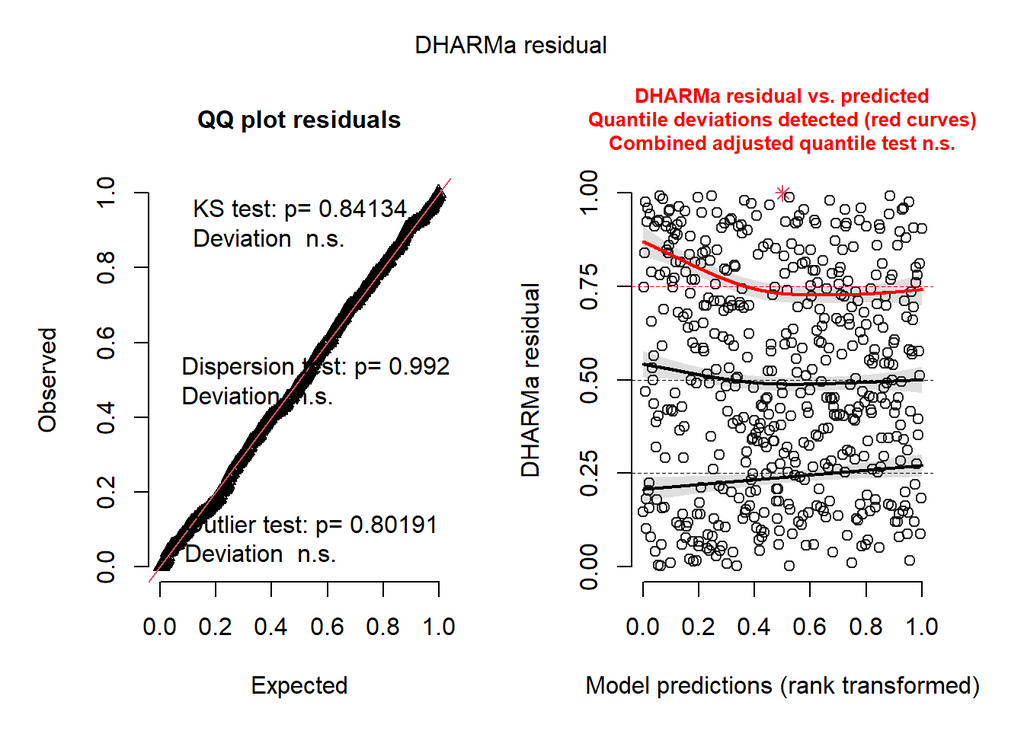

```r
res <- simulateResiduals(final_recovery_model)
plot(res)
```

```r
summary(final_recovery_model)
```

```
##  Family: tweedie  ( log )
## Formula:
## keystrokes ~ condition * domain + scale(num_characters) + scale(num_minor) +
##     scale(num_major) + scale(MT_Quality) + scale(Difficulty) +
##     (1 | PET) + (1 | text_name/Sent_id)
## Data: data
##
##       AIC       BIC    logLik -2*log(L)  df.resid
##    4487.6    4563.3   -2225.8    4451.6       478
##
## Random effects:
##
## Conditional model:
##  Groups            Name        Variance Std.Dev.
##  PET               (Intercept) 0.24305  0.4930
##  Sent_id:text_name (Intercept) 0.19266  0.4389
##  text_name         (Intercept) 0.06014  0.2452
## Number of obs: 496, groups:  PET, 8; Sent_id:text_name, 62; text_name, 8
##
## Dispersion parameter for tweedie family ():  4.7
##
## Conditional model:
##                       Estimate Std. Error z value Pr(>|z|)
## (Intercept)            3.51186    0.25558  13.741  < 2e-16 ***
## condition2            -0.10173    0.17166  -0.593 0.553429
## condition3             0.04825    0.15716   0.307 0.758862
## condition4            -0.05910    0.15299  -0.386 0.699265
## domainnews            -0.07359    0.25094  -0.293 0.769312
## scale(num_characters)  0.36750    0.06919   5.311 1.09e-07 ***
## scale(num_minor)       0.05409    0.05554   0.974 0.330083
## scale(num_major)       0.06744    0.04258   1.584 0.113257
## scale(MT_Quality)     -0.16056    0.04422  -3.631 0.000282 ***
## scale(Difficulty)      0.11245    0.05597   2.009 0.044529 *
## condition2:domainnews  0.19956    0.19111   1.044 0.296385
## condition3:domainnews  0.19469    0.18488   1.053 0.292329
## condition4:domainnews  0.08572    0.18722   0.458 0.647066
## ---
## Signif. codes:  0 '***' 0.001 '**' 0.01 '*' 0.05 '.' 0.1 ' ' 1
```

### Visualising random intercepts

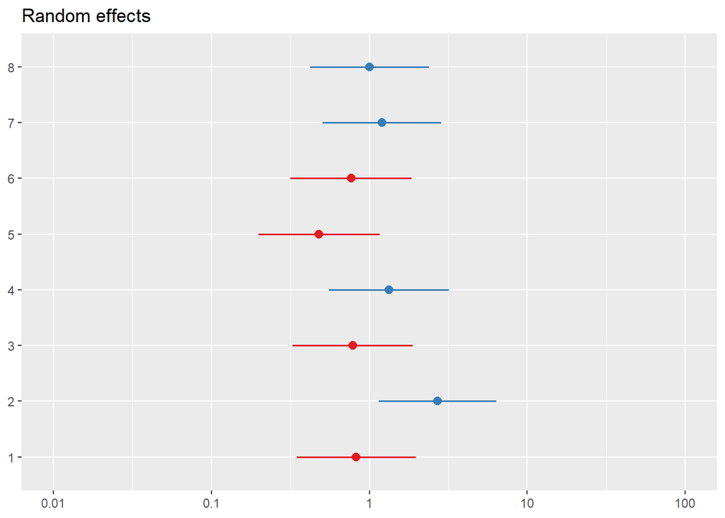

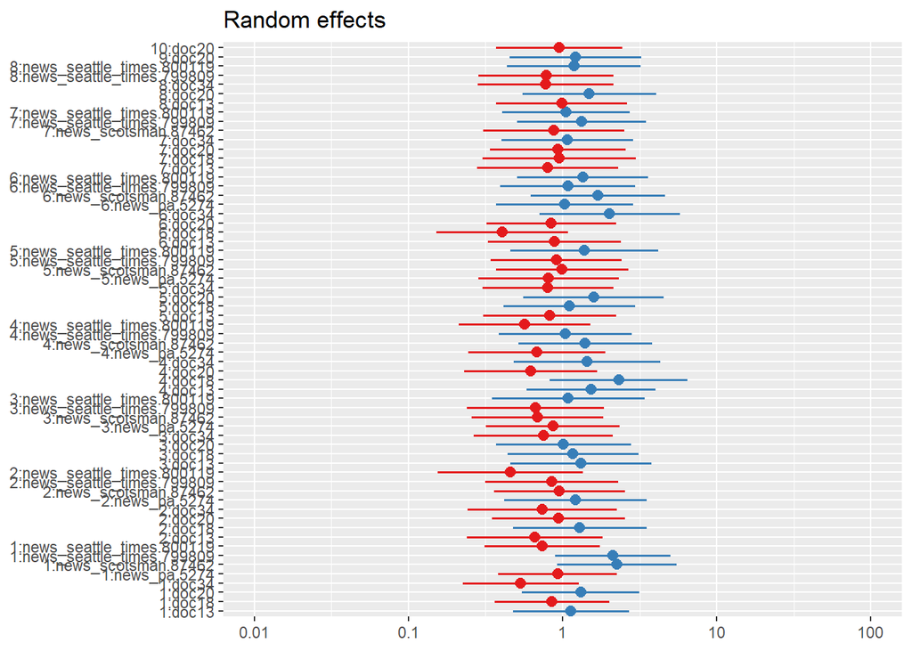

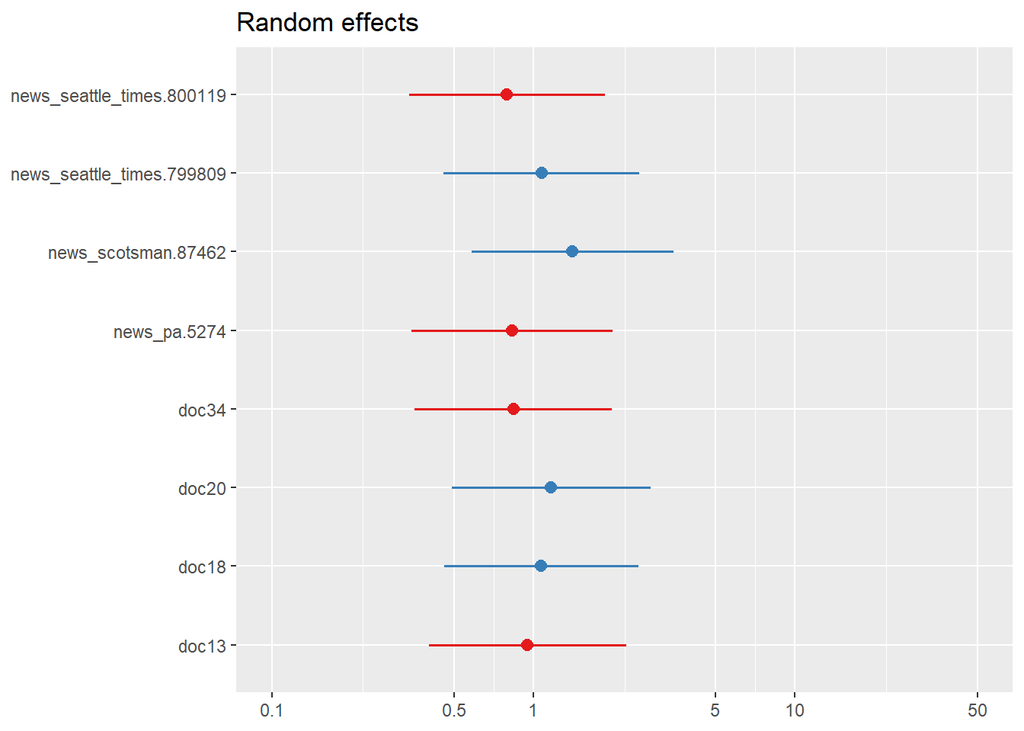

```r
plot_model(final_recovery_model, type = "re")
```

### Simplifying the model to make residuals homoschedastic

```r
# Creating the simplified version: no interaction term
reduced_model <- update(final_recovery_model, . ~ . - condition:domain)

# Compare them
anova(final_recovery_model, reduced_model)
```

```
## Data: data
## Models:
## reduced_model: keystrokes ~ condition + domain + scale(num_characters) + scale(num_minor) + , zi=~0, disp=~1
## reduced_model:     scale(num_major) + scale(MT_Quality) + scale(Difficulty) + , zi=~0, disp=~1
## reduced_model:     (1 | PET) + (1 | text_name/Sent_id), zi=~0, disp=~1
## final_recovery_model: keystrokes ~ condition * domain + scale(num_characters) + scale(num_minor) + , zi=~0, disp=~1
## final_recovery_model:     scale(num_major) + scale(MT_Quality) + scale(Difficulty) + , zi=~0, disp=~1
## final_recovery_model:     (1 | PET) + (1 | text_name/Sent_id), zi=~0, disp=~1
##                      Df    AIC    BIC  logLik deviance  Chisq Chi Df Pr(>Chisq)
## reduced_model        15 4483.1 4546.2 -2226.6   4453.1
## final_recovery_model 18 4487.6 4563.3 -2225.8   4451.6 1.5615      3     0.6682
```

```r
# no significant differences in predictive power and AIC and BIC are lower, we keep the reduced

# Check Variance Inflation Factors
performance::check_collinearity(final_recovery_model) # since the full model has interaction terms. VIFs might be affected
```

```
## Model has interaction terms. VIFs might be inflated.
##   Try to center the variables used for the interaction, or check
##   multicollinearity among predictors of a model without interaction terms.
```

```
## # Check for Multicollinearity
##
## Low Correlation
##
##                   Term  VIF     VIF 95% CI adj. VIF Tolerance Tolerance 95% CI
##                 domain 1.33 [ 1.22,  1.51]     1.15      0.75     [0.66, 0.82]
##  scale(num_characters) 1.10 [ 1.04,  1.28]     1.05      0.91     [0.78, 0.97]
##       scale(num_minor) 2.34 [ 2.06,  2.70]     1.53      0.43     [0.37, 0.48]
##       scale(num_major) 1.61 [ 1.44,  1.83]     1.27      0.62     [0.55, 0.69]
##      scale(MT_Quality) 1.21 [ 1.12,  1.38]     1.10      0.82     [0.73, 0.89]
##      scale(Difficulty) 1.21 [ 1.11,  1.37]     1.10      0.83     [0.73, 0.90]
##
## High Correlation
##
##              Term   VIF     VIF 95% CI adj. VIF Tolerance Tolerance 95% CI
##         condition 16.79 [14.25, 19.82]     4.10      0.06     [0.05, 0.07]
##  condition:domain 11.57 [ 9.84, 13.63]     3.40      0.09     [0.07, 0.10]
```

```r
performance::check_collinearity(reduced_model) # here no highly correlated variables
```

```
## # Check for Multicollinearity
##
## Low Correlation
##
##                   Term  VIF   VIF 95% CI adj. VIF Tolerance Tolerance 95% CI
##              condition 2.95 [2.57, 3.42]     1.72      0.34     [0.29, 0.39]
##                 domain 1.05 [1.01, 1.33]     1.02      0.95     [0.75, 0.99]
##  scale(num_characters) 1.09 [1.03, 1.28]     1.05      0.91     [0.78, 0.97]
##       scale(num_minor) 2.14 [1.89, 2.46]     1.46      0.47     [0.41, 0.53]
##       scale(num_major) 1.59 [1.43, 1.80]     1.26      0.63     [0.55, 0.70]
##      scale(MT_Quality) 1.18 [1.10, 1.35]     1.09      0.85     [0.74, 0.91]
##      scale(Difficulty) 1.17 [1.08, 1.33]     1.08      0.86     [0.75, 0.92]
```